# ML-Project

Rahul Jain

18/03/2022

## Instructions

Using devices such as Jawbone Up, Nike FuelBand, and Fitbit it is now possible to collect a large amount of data about personal activity relatively inexpensively. These type of devices are part of the quantified self movement – a group of enthusiasts who take measurements about themselves regularly to improve their health, to find patterns in their behavior, or because they are tech geeks. One thing that people regularly do is quantify how much of a particular activity they do, but they rarely quantify how well they do it.

In this project, your goal will be to use data from accelerometers on the belt, forearm, arm, and dumbell of 6 participants. They were asked to perform barbell lifts correctly and incorrectly in 5 different ways. More information is available from the website [here](http://web.archive.org/web/20161224072740/http:/groupware.les.inf.puc-rio.br/har) (see the section on the Weight Lifting Exercise Dataset).  
The goal of your project is to predict the manner in which they did the exercise. This is the “classe” variable in the training set. You may use any of the other variables to predict with. You should create a report describing how you built your model, how you used cross validation, what you think the expected out of sample error is, and why you made the choices you did. You will also use your prediction model to predict 20 different test cases.

## Data

The training data for this project are available [here](https://d396qusza40orc.cloudfront.net/predmachlearn/pml-training.csv)  
The test data are available [here](https://d396qusza40orc.cloudfront.net/predmachlearn/pml-testing.csv)

# Analysis

## Summary

I read the documentation shared within the assignment to find insights about the data and decided to fit Random Forest and Gradient Boosting algorithm to data. From the model fit and accuracy metrics, I observed that accuracy for Random Forest was 99.76% for test data as compared to GBM which was around 98.8% i.e, 1% higher for Random Forest as compared to GBM with cross validation for fitting multiple models to the data to find the best model. Below report details the steps that I covered for the analysis.

## Library Import

```r
library(caret)
library(randomForest)
```

```r
library(ggplot2)
```

## Data Download

```r
download.file(url = 'https://d396qusza40orc.cloudfront.net/predmachlearn/pml-training.csv',
                destfile = 'train.csv', method = 'curl', quiet = TRUE)
download.file(url = 'https://d396qusza40orc.cloudfront.net/predmachlearn/pml-testing.csv',
                destfile = 'test.csv', method = 'curl', quiet = TRUE)
```

## Data Import

```r
trainData <- read.csv("train.csv")
testData <- read.csv("test.csv")
```

## Preprocessing

#### Looking at structure of the data

```r
str(trainData)
```

```
## 'data.frame':    19622 obs. of  160 variables:
##  $ X                       : int  1 2 3 4 5 6 7 8 9 10 ...
##  $ user_name               : chr  "carlitos" "carlitos" "carlitos" "carlitos" ...
##  $ raw_timestamp_part_1    : int  1323084231 1323084231 1323084231 1323084232 1323084232 1323084232 1323084232 1323084232 1323084232 1323084232 ...
##  $ raw_timestamp_part_2    : int  788290 808298 820366 120339 196328 304277 368296 440390 484323 484434 ...
##  $ cvtd_timestamp          : chr  "05/12/2011 11:23" "05/12/2011 11:23" "05/12/2011 11:23" "05/12/2011 11:23" ...
##  $ new_window              : chr  "no" "no" "no" "no" ...
##  $ num_window              : int  11 11 11 12 12 12 12 12 12 12 ...
##  $ roll_belt               : num  1.41 1.41 1.42 1.48 1.48 1.45 1.42 1.42 1.43 1.45 ...
##  $ pitch_belt              : num  8.07 8.07 8.07 8.05 8.07 8.06 8.09 8.13 8.16 8.17 ...
##  $ yaw_belt                : num  -94.4 -94.4 -94.4 -94.4 -94.4 -94.4 -94.4 -94.4 -94.4 -94.4 ...
##  $ total_accel_belt        : int  3 3 3 3 3 3 3 3 3 3 ...
##  $ kurtosis_roll_belt      : chr  "" "" "" "" ...
##  $ kurtosis_picth_belt     : chr  "" "" "" "" ...
##  $ kurtosis_yaw_belt       : chr  "" "" "" "" ...
```

[output cut: 86 more lines]

There are around 160 variables in the training set with 19622 observations. As there are lots of variables within the dataset, exploring data by visualization would be very time consuming. We can use pdf given in the assignment to understand the data more. Link -> http://web.archive.org/web/20161224072740/http:/groupware.les.inf.puc-rio.br/har

Removing first 5 columns from the dataset as they are not related to the exercise

```r
trainData <- trainData[,6:ncol(trainData)]
```

#### Splitting of training data into train and test set

```r
set.seed(42)
inTrain <- createDataPartition(trainData$classe,p=0.7,list = FALSE)
training <- trainData[inTrain,]
testing <- trainData[-inTrain,]
```

```r
nzv <- nearZeroVar(trainData,saveMetrics = TRUE)
keepFt <- row.names(nzv[nzv$nzv==FALSE,])
training <- training[,keepFt]
```

After removing similar variables, we have around 95 features left within data. We can also remove variables with missing values

#### Remove variables with lot of missing data

```r
training <- training[,colSums(is.na(training)) == 0]
```

After removing variables with missing data, we have around 54 variables left

## Model Training

### Setting up cross validation control

```r
cv <- trainControl(method = "cv",number = 5)
```

### Random Forest Model

#### Fitting Random Forest Model

```r
set.seed(42)
fitRF <- train(classe~.,data = training,method="rf",trControl = cv)
```

#### Summary of model fit with Ramdon Forest

```r
fitRF$finalModel
```

```
##
## Call:
##  randomForest(x = x, y = y, mtry = min(param$mtry, ncol(x)))
##                Type of random forest: classification
##                      Number of trees: 500
## No. of variables tried at each split: 27
##
##         OOB estimate of  error rate: 0.2%
## Confusion matrix:
##      A    B    C    D    E  class.error
## A 3904    2    0    0    0 0.0005120328
## B    6 2648    3    1    0 0.0037622272
## C    0    3 2393    0    0 0.0012520868
## D    0    0    8 2244    0 0.0035523979
## E    0    1    0    4 2520 0.0019801980
```

Out of bag samples error rate is 0.2% which is very good

#### Checking model accuracy on testing set

```r
predRF <- predict(fitRF, newdata = testing)
confusionMatrix(predRF,factor(testing$classe))
```

```
## Confusion Matrix and Statistics
##
##           Reference
## Prediction    A    B    C    D    E
##          A 1674    1    0    0    0
##          B    0 1136    3    0    0
##          C    0    2 1023    4    0
##          D    0    0    0  959    3
##          E    0    0    0    1 1079
##
## Overall Statistics
##
##                Accuracy : 0.9976
##                  95% CI : (0.996, 0.9987)
##     No Information Rate : 0.2845
##     P-Value [Acc > NIR] : < 2.2e-16
##
##                   Kappa : 0.997
##
##  Mcnemar's Test P-Value : NA
##
## Statistics by Class:
##
##                      Class: A Class: B Class: C Class: D Class: E
## Sensitivity            1.0000   0.9974   0.9971   0.9948   0.9972
## Specificity            0.9998   0.9994   0.9988   0.9994   0.9998
## Pos Pred Value         0.9994   0.9974   0.9942   0.9969   0.9991
## Neg Pred Value         1.0000   0.9994   0.9994   0.9990   0.9994
## Prevalence             0.2845   0.1935   0.1743   0.1638   0.1839
## Detection Rate         0.2845   0.1930   0.1738   0.1630   0.1833
## Detection Prevalence   0.2846   0.1935   0.1749   0.1635   0.1835
## Balanced Accuracy      0.9999   0.9984   0.9979   0.9971   0.9985
```

On testing data Random Forest shows 99.76% accuracy which should be very hard to beat.

### Gradient Bossting Model

#### Fitting GBM Model

```r
fitGBM <- train(classe~.,data = training, method = "gbm", trControl = cv, verbose = FALSE)
```

#### Summary of model fit with GBM

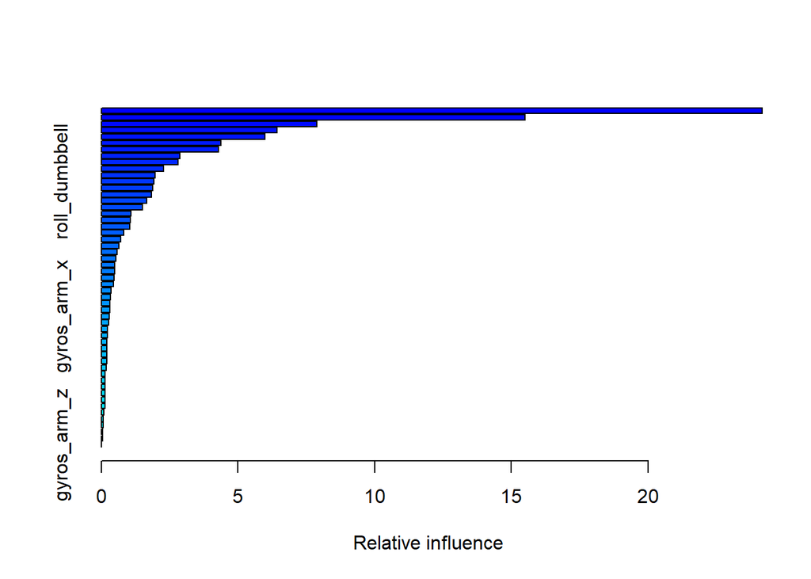

```
##                                       var      rel.inf
## num_window                     num_window 24.169250996
## roll_belt                       roll_belt 15.502227565
## pitch_forearm               pitch_forearm  7.873321839
## magnet_dumbbell_z       magnet_dumbbell_z  6.415302942
## yaw_belt                         yaw_belt  5.973257391
## magnet_dumbbell_y       magnet_dumbbell_y  4.361978441
## roll_forearm                 roll_forearm  4.284016995
## magnet_belt_z               magnet_belt_z  2.878804557
## pitch_belt                     pitch_belt  2.799618210
## accel_dumbbell_z         accel_dumbbell_z  2.275782906
## accel_forearm_x           accel_forearm_x  1.955990419
## roll_dumbbell               roll_dumbbell  1.922554853
## accel_dumbbell_y         accel_dumbbell_y  1.869281710
## gyros_belt_z                 gyros_belt_z  1.834996295
## gyros_dumbbell_y         gyros_dumbbell_y  1.662340007
## magnet_forearm_z         magnet_forearm_z  1.496010861
## accel_dumbbell_x         accel_dumbbell_x  1.085553520
## yaw_arm                           yaw_arm  1.059361588
## magnet_belt_x               magnet_belt_x  1.050763648
## accel_forearm_z           accel_forearm_z  0.818781364
## magnet_arm_z                 magnet_arm_z  0.709232800
## gyros_arm_y                   gyros_arm_y  0.636988566
## accel_belt_z                 accel_belt_z  0.579148312
## magnet_arm_y                 magnet_arm_y  0.524415792
## magnet_belt_y               magnet_belt_y  0.482835934
## magnet_dumbbell_x       magnet_dumbbell_x  0.482493043
## magnet_forearm_x         magnet_forearm_x  0.455365172
## gyros_dumbbell_x         gyros_dumbbell_x  0.437064794
## roll_arm                         roll_arm  0.344823995
## magnet_arm_x                 magnet_arm_x  0.324187115
## total_accel_dumbbell total_accel_dumbbell  0.313729273
## gyros_belt_y                 gyros_belt_y  0.311718072
## gyros_arm_x                   gyros_arm_x  0.291915022
## accel_forearm_y           accel_forearm_y  0.264097103
## magnet_forearm_y         magnet_forearm_y  0.231435214
## gyros_forearm_z           gyros_forearm_z  0.218362807
## accel_arm_y                   accel_arm_y  0.212046538
## pitch_arm                       pitch_arm  0.203191313
## accel_arm_x                   accel_arm_x  0.200442125
## accel_arm_z                   accel_arm_z  0.190231399
## gyros_dumbbell_z         gyros_dumbbell_z  0.174816847
## pitch_dumbbell             pitch_dumbbell  0.137972978
## total_accel_forearm   total_accel_forearm  0.133594443
## yaw_forearm                   yaw_forearm  0.132746974
## gyros_forearm_y           gyros_forearm_y  0.131093200
## total_accel_arm           total_accel_arm  0.129054957
## gyros_belt_x                 gyros_belt_x  0.124332263
## yaw_dumbbell                 yaw_dumbbell  0.085098023
## total_accel_belt         total_accel_belt  0.075976247
## gyros_forearm_x           gyros_forearm_x  0.073245115
## accel_belt_x                 accel_belt_x  0.056740291
## accel_belt_y                 accel_belt_y  0.037398329
## gyros_arm_z                   gyros_arm_z  0.005009835
```

```r
summary(fitGBM$finalModel)
```

Plot and table shows relative influence of each variable on the model fit. Top variables are: 1) num_window 2) roll_belt 3)pitch_forearm

#### Checking accuracy and other statistics

```r
predGBM <- predict(fitGBM, newdata = testing)
confusionMatrix(predGBM,factor(testing$classe))
```

```
## Confusion Matrix and Statistics
##
##           Reference
## Prediction    A    B    C    D    E
##          A 1671    7    0    1    0
##          B    3 1122   12    3    5
##          C    0    7 1014   10    4
##          D    0    3    0  948   11
##          E    0    0    0    2 1062
##
## Overall Statistics
##
##                Accuracy : 0.9884
##                  95% CI : (0.9854, 0.991)
##     No Information Rate : 0.2845
##     P-Value [Acc > NIR] : < 2.2e-16
##
##                   Kappa : 0.9854
##
##  Mcnemar's Test P-Value : NA
##
## Statistics by Class:
##
##                      Class: A Class: B Class: C Class: D Class: E
## Sensitivity            0.9982   0.9851   0.9883   0.9834   0.9815
## Specificity            0.9981   0.9952   0.9957   0.9972   0.9996
## Pos Pred Value         0.9952   0.9799   0.9797   0.9854   0.9981
## Neg Pred Value         0.9993   0.9964   0.9975   0.9967   0.9959
## Prevalence             0.2845   0.1935   0.1743   0.1638   0.1839
## Detection Rate         0.2839   0.1907   0.1723   0.1611   0.1805
## Detection Prevalence   0.2853   0.1946   0.1759   0.1635   0.1808
## Balanced Accuracy      0.9982   0.9901   0.9920   0.9903   0.9905
```

GBM Model has accuracy of around 98.84% which is lower as compared to Random Forest